# Dog Survey Analysis

```r
library(tidyverse)
library(janitor)
library(ggplot2)
library(here)
```

```r
dog_survey_clean <- read_csv(here("data/clean_data/dog_survey_clean.csv"))
```

# Dog Survey Analysis

## The Raw Data

The *raw data* came in the form of a `.csv` file (dog_survey.csv). This contained information about the dog owner as well as some information about the dog - `age`, `gender`, `size`. Aside from the 2 empty columns at the end there was not a lot of *missing data*. Possibly some people not wanting to reveal how much they spend on dog food.

### Additional Data for Further Analysis

It could be useful to have more data on costs involved with the dog. Such as vet bills or grooming bills. If I had this data I could carry out further analysis on the total cost of having a dog.

## Assumptions

I assumed that the `dog_age` and `amount_spend_on_dog_food` should be numerical fields, they were initialy of type *character*. This would be required for any statistical analysis.

## Cleaning Process Overview

I have a `.R script` containing my whole cleaning process (dog_survey_cleaning.R). I wrote the final cleaned table to a `.csv` file (dog_survey_clean.csv), which has been read in at the top of this document. Here is an overview of my cleaning steps.

- Read in *raw data*
- Remove empty columns
- *Clean* the column header names
- Change the `dog_age` and `spend_on_food` columns to numeric
- Remove any **duplicated** data
- *Clean* up the data inside the `dog_gender` and `dog_size` columns so that only certain values are allowed
- write the final data to a `.csv`

## Task Analysis

*1. The client only counts a valid email address as one ending in ‘.com’. How many survey results have a valid email address.*

```r
dog_survey_valid_email <- dog_survey_clean %>%
  mutate(valid_email = str_detect(email, "\\.com"), .after = email) %>%
  filter(valid_email == TRUE) %>%
  summarise(n_valid_emails = n())

dog_survey_valid_email
```

| n_valid_emails |
| --- |
| 187 |

*2. What’s the average amount spent on dog food for each dog size.*

```r
dog_survey_avg_spend <- dog_survey_clean %>%
  drop_na(spend_on_food) %>%
  group_by(dog_size) %>%
  summarise(avg_spend = round(mean(spend_on_food), 2))
dog_survey_avg_spend
```

| dog_size | avg_spend |
| --- | --- |
| l | 48.97 |
| m | 46.95 |
| s | 50.32 |
| xl | 51.07 |
| xs | 57.30 |
| NA | 58.56 |

```r
NA
```

*3. For owners whose surname starts with a letter in the second half of the alphabet (N onwards) what is the average age of their dog?*

- I have **filtered** the `last_name` column to only give us names starting with “N-Z”. Then found the **average** age of their dog (in dog years). This is 53.3.

```r
dog_survey_surname <- dog_survey_clean %>%
  mutate(last_name = str_to_title(last_name)) %>%
  filter(str_detect(last_name, "^[N-Z]")) %>%
  drop_na(dog_age) %>%
  summarise(avg_dog_age = round(mean(dog_age), 2))
dog_survey_surname
```

| avg_dog_age |
| --- |
| 53.3 |

*4. The dog_age column is the age in dog years. If the conversion is 1 human year = 6 dog years, then what is the average human age for dogs of each gender?*

- Here I have calculated the `human_age` by taking the number in `dog_years` and dividing it by 6. I then worked out the **average** age in `dog_years` and `human_years` for each gender. This shows that the average `male` dogs used for this survey were slightly older than the average `female`.

```r
dog_survey_human_age <- dog_survey_clean %>%
  drop_na(dog_age) %>%
  mutate(human_age = dog_age /6) %>%
  group_by(dog_gender) %>%
  summarise(dog_years = round(mean(dog_age), 2),
            human_years = round(mean(human_age),2))
dog_survey_human_age
```

| dog_gender | dog_years | human_years |
| --- | --- | --- |
| female | 47.67 | 7.95 |
| male | 50.63 | 8.44 |
| unknown | 51.10 | 8.52 |

*5. Create a plot of results of question 4.*

- Here I have **plotted** the average `dog_age` by `gender` (in dog years and human years). This shows the males being slightly older than the females but not quite as old as the “unknown” category.

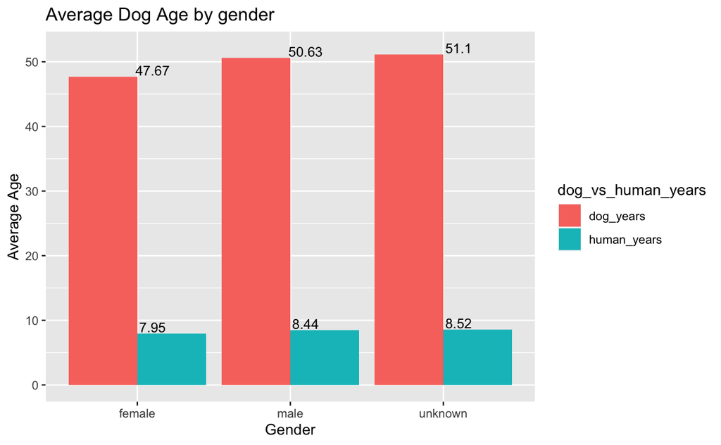

```r
dog_pivot <- dog_survey_human_age %>%
  pivot_longer(cols = 2:3,
               names_to = "dog_vs_human_years",
               values_to = "avg_age")


dog_ages_plot <- ggplot(dog_pivot,
       aes(x = dog_gender,
           y= avg_age,
           fill= dog_vs_human_years)) +
  geom_bar(stat="identity", position=position_dodge()) +
  ggtitle("Average Dog Age by gender") +
  xlab("Gender") +
  ylab("Average Age") +
  geom_text(aes(label = avg_age),
            colour="black",
            size=3.5,
            nudge_x = 0.1,
            nudge_y = 1)
dog_ages_plot
```